# Predicting Cane Toad Expansion in Australia

Nicholas Boffa u7686660

22/04/2024

# Load Libraries and set.seed()

```r
set.seed(8723)

library(R6)
library(tidyverse)
library(animation)
library(raster)
library(randomForest)
library(sf)
library(gridExtra)
library(viridis)
library(cowplot)
library(skimr)
library(grid)
library(knitr)
source("ABM.R")
```

# Word/figure count

Words: 1988 Figures:6

# Location on GitHub

https://github.com/nickboffa/DS4B-final-report

# Project Outline

## Aim

To use environmental data, together with outputs from mechanistic models, to try to replicate (and then predict) the colonisation of Australia by cane toads using an agent-based model (ABM).

## Justification

Many attempts have been made to model the environmental niche of cane toads, but their range-shifting nature has made this difficult (Elith et. al, 2010). The traditional method is the ‘correlative’ approach: using a set of environmental predictor variables, together with some algorithm (e.g. GAM), to predict the fundamental niche of a species - such as in Urban et. al (2008). However, particularly, with cane toads such models tend to be inaccurate as they have not reached equilibrium with their fundamental niche (Elith et. al, 2010).

Kearney et. al (2008) resolved this issue by only using the physiology of cane toads to predict their fundamental niche (the ‘mechanistic’ approach), and found that access to breeding sites was the primary limiter to the toads invasion inland. But this approach can only model finite biological mechanisms, and so may miss key aspects determining the toad’s fundamental niche.

At the recommendation of Kearney et. al (2008) and as implemented by Elith et. al (2010), we will thus use this mechanistic output, that tells where the cane toads should be theoretically able to live, to define the pseudoabsence points that then inform our correlative model; we shall also incorporate the recent recommendations of Soley-Guardia et. al (2024).

The key difference in this report to the primary literature is the use of an ABM. By introducing a temporal component to the model, we can predict not just where the toad’s will end up, but when they will arrive there. We shall only use occurrence data up to the year 2000, so that we may validate our model with present-day data.

# Raw data description

## Atlas of Living Australia

The dataset comprises occurrence records (with coordinates) of cane toads in Australia (*Rhinella marina*), downloaded from the Atlas of Living Australia (ALA). ALA is a nationally recognised data repository that collates biodiversity data from multiple sources. For more information see Belbin et al. (2021).

The raw data was obtained by pressing ‘download’ in this webpage: https://biocache.ala.org.au/occurrences/search?q=lsid:https://biodiversity.org.au/afd/taxa/5c8e5d04-49dd-43ec-b9e0-f4e55ee82407#tab_recordsView

```r
df<-read_csv("processed_data/cleaned_data.csv")
sp_df<-df
coordinates(sp_df)<-c("longitude", "latitude")
```

## WorldClim 2.1

In this report we use 2 of the 19 bioclimatic variables available in WorldClim 2.1 (Fick & Hijmans, 2017) at a resolution of 10 minutes, downloaded by running in R:

geodata::worldclim_global(var=“bio”, res=10, path=“where/you/want/the/folder/to/be”)

These variables are raster surfaces for the entire globe, where the values are the average from 1970-2000. For variable descriptions, see O’Donnell & Ignizio (2012). The two we use are

$$\text{Isothermality}=100\cdot\frac{\text{Average
difference between maximum temp and minimum temp in a
month}}{\text{Annual temperature range}}$$

$$\text{Precipitation of Driest Quarter
(PDQ)}=\text{Total precipitation (mm) that fell in driest 3 months of
year}$$

```r
bioclim_stack<-stack("processed_data/bioclim_stack.grd")
```

## Breeding Figure

Kearney et. al (2008) used the biology of cane toads to predict where they would be able to survive. We will use their results to inform our model. We took a screenshot of Figure S1 from their supplementary material, bounded by the northernmost, easternmost, westernmost points of Australia, and the southernmost point of Tasmania. We then converted this to a raster (henceforth “breeding raster”).

```r
breeding<-raster("processed_data/breeding.grd")
```

## Australia outline

Outline was downloaded using geodata::gadm(country = “AUS”, level=0, path=tempdir()), then mainland outline extracted.

```r
australia_sf<-st_read("processed_data/mainland_australia.shp")
australia_spatial<-as(australia_sf, "Spatial")
```

For the ABM, we’ll use the outline of the actual grid:

```r
australia_raster<-raster("processed_data/australia_raster.grd")
australia_polygons<-rasterToPolygons(australia_raster, fun=function(x) x == 1, dissolve=TRUE)
abm_sf<-st_as_sf(australia_polygons)
st_crs(abm_sf)<-4326
```

# Sanity checks

Checking if dataframe values seem right:

```r
skim(df)
```

Data summary

| Name | df |
| --- | --- |
| Number of rows | 33262 |
| Number of columns | 7 |
| _______________________ |  |
| Column type frequency: |  |
| character | 2 |
| numeric | 4 |
| POSIXct | 1 |
| ________________________ |  |
| Group variables | None |

**Variable type: character**

| skim_variable | n_missing | complete_rate | min | max | empty | n_unique | whitespace |
| --- | --- | --- | --- | --- | --- | --- | --- |
| stateProvince | 0 | 1.00 | 10 | 18 | 0 | 4 | 0 |
| locality | 11903 | 0.64 | 3 | 224 | 0 | 6061 | 0 |

**Variable type: numeric**

| skim_variable | n_missing | complete_rate | mean | sd | p0 | p25 | p50 | p75 | p100 | hist |
| --- | --- | --- | --- | --- | --- | --- | --- | --- | --- | --- |
| year | 1213 | 0.96 | 2009.42 | 14.09 | 1900.00 | 2004.00 | 2015.00 | 2019.00 | 2024.00 | ▁▁▁▂▇ |
| longitude | 0 | 1.00 | 144.83 | 8.63 | 122.22 | 134.49 | 146.81 | 153.01 | 153.64 | ▁▅▁▃▇ |
| latitude | 0 | 1.00 | -20.99 | 6.32 | -34.16 | -27.46 | -20.12 | -14.26 | -10.17 | ▁▇▂▃▆ |
| id | 0 | 1.00 | 16836.61 | 9716.32 | 1.00 | 8456.25 | 16834.50 | 25245.75 | 33694.00 | ▇▇▇▇▇ |

**Variable type: POSIXct**

| skim_variable | n_missing | complete_rate | min | max | median | n_unique |
| --- | --- | --- | --- | --- | --- | --- |
| eventDate | 3816 | 0.89 | 1900-01-01 | 2024-04-20 09:12:51 | 2014-08-09 | 9096 |

Checking where toad observations are (dark grey is the breeding raster)

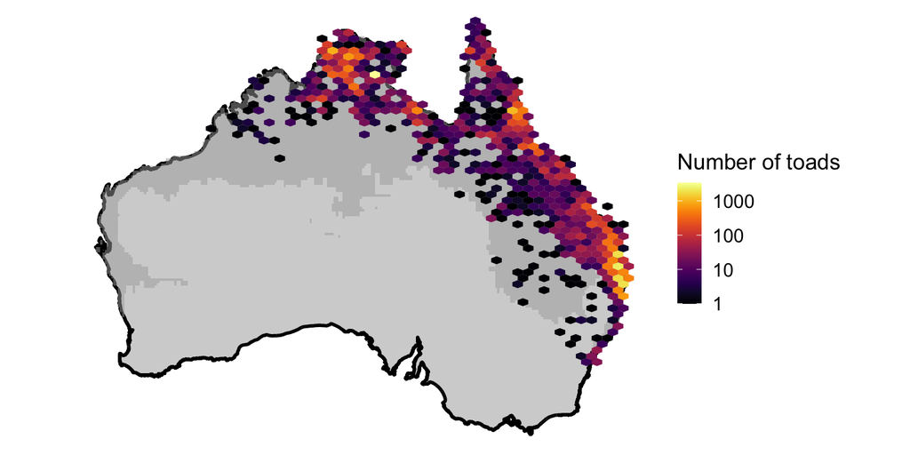

```r
ggplot(df) +
  geom_sf(data=australia_sf, fill = 'lightgrey', color = "black", linewidth=1) +
  geom_raster(data=filter(as.data.frame(rasterToPoints(breeding)), layer == 1), aes(x=x, y=y), fill = "darkgrey", alpha=0.5) +
  geom_hex(aes(x=longitude, y=latitude), bins=50) +
  scale_fill_viridis(trans = "log10", option='inferno') +
  theme_nothing() +
  theme(legend.position = 'right') +
  labs(fill='Number of toads')
```

Checking that input WorldClim layers and manipulated breeding raster look correct.

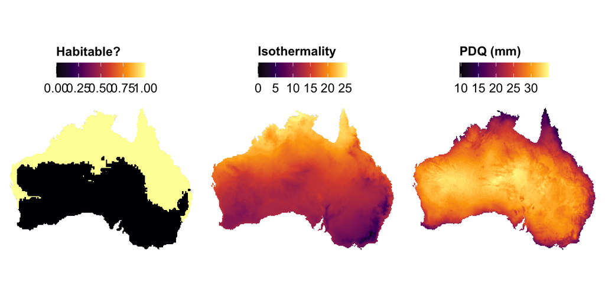

```r
# ChatGPT, 2024
rasters<-list(
  "Habitable?"=breeding,
  "Isothermality"=bioclim_stack[["Isothermality"]],
  "PDQ (mm)"=bioclim_stack[["Precipitation.of.Driest.Quarter"]]
)

create_raster_plot<-function(raster_data, title) {
  raster_df<-as.data.frame(rasterToPoints(raster_data))
  colnames(raster_df) <- c("x", "y", "value")
  ggplot() +
  geom_sf(data=australia_sf, fill = 'lightgrey', color = "black", linewidth=0) +
  geom_raster(data=raster_df, aes(x=x, y=y, fill=value)) +
  scale_fill_viridis_c(option = 'inferno', name=title) +
  theme_void() +
  theme(
    legend.position = 'top',
    legend.title=element_text(size=12, face = "bold"),
    legend.text=element_text(size=12),
    legend.title.position = 'top',
    legend.justification = "center"
  ) +
  guides(fill=guide_colorbar(barwidth=unit(3, "cm"), barheight=unit(0.5, "cm")))
}


raster_plots<-lapply(names(rasters), function(name) {
  create_raster_plot(rasters[[name]], name)
})

input_plot<-plot_grid(plotlist=raster_plots, ncol=3)
input_plot
```

Everything seems fine.

# Addressing the questions/aims

## Machine Learning

### Create cell_df

For the random forest to work, we divide Australia into a grid, count the number of occurrences in each cell, get the values of the predictor variables in each cell, and then see if the model can predict where toads should be based on the predictors. Hence, we need a dataframe where each row is a gridcell, and the columns specify its location, the number of toads in it, and the predictors (WorldClim layers).

Since we don’t have the locations of where the toads aren’t, we must guess (create ‘pseudoabsences’). For this, we use the predictions of Kearney et. al (2008) in the breeding raster.

```r
create_cell_df<-function(data, env, years_up_to=2024) {
  data<-subset(data, year < years_up_to)

  toad_counts<-rasterize(data, env, fun="count", background=NA)[["ID"]]
  toad_counts[breeding == 0]<-0
  toad_count_df<-as.data.frame(toad_counts, xy=TRUE)

  cell_df<-cbind(toad_count_df, as.data.frame(extract(env, toad_count_df[,1:2], method='bilinear')))
  cell_df<-na.omit(cell_df)
  rownames(cell_df)<-NULL

  cell_df<-cell_df |>
    rename(longitude="x",
           latitude="y",
           n_toads="ID")

  cell_df$any_toads<-cell_df$n_toads > 0

  return(cell_df)
}
```

```r
cell_df<-create_cell_df(sp_df, bioclim_stack, years_up_to=2000)
```

### Create model

Since occurrence data is extremely biased by population density, we shall allow only a maximum of one observation per cell (avoiding Hazard 2 in Soley-Guardia et. al (2024)). To further prevent overfitting to this bias, we limit the number of trees and maximum number of terminal nodes in each tree (avoiding Hazard 4). We also only consider mainland Australia (avoiding Hazard 6).

Isothermality and PDQ have also been thought to biologically affect toad distribution, so their inclusion is reasonable (Elith et. al, 2010). Our model then produces something similar to the breeding_raster.

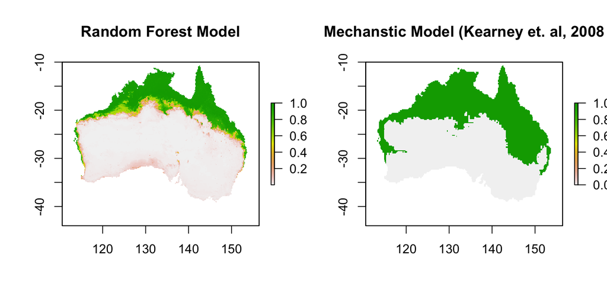

```r
rf_model<-randomForest(any_toads ~ Isothermality + Precipitation.of.Driest.Quarter, data=cell_df,
                         ntree=100, maxnodes=50)

predictions<-predict(bioclim_stack, model=rf_model)

par(mfrow=c(1, 2))
plot(predictions, main="Random Forest Model")
plot(breeding, main="Mechanstic Model (Kearney et. al, 2008")
```

We can see that the number of trees was sufficient for the error rate to stabilise, and isothermality was more useful than PDQ in predicting where toads are (has a higher inc node purity).

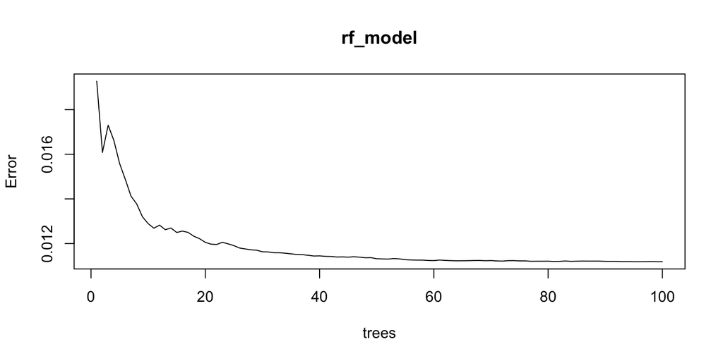

```r
plot(rf_model)
```

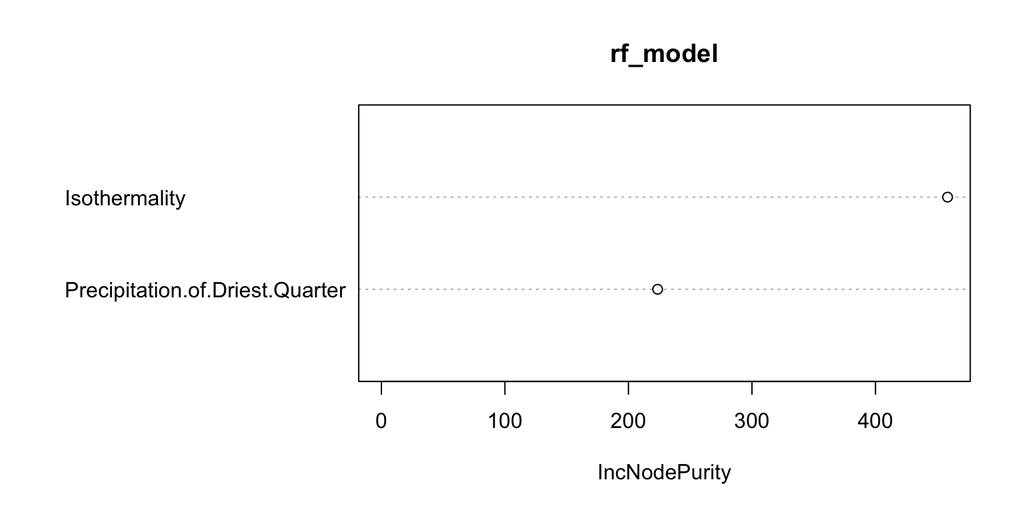

```r
varImpPlot(rf_model)
```

## ABM

The model begins with two toads, in the two locations toads were first released (~Cairns and ~Brisbane). In discrete timesteps, and independently of other toads, each toad then: 1. moves 2. updates its ‘energy’ 3. Depending on its new energy, dies, reproduces, or does nothing as appropriate.

### Behaviours and Attributes

#### Moving

Toads can only move to cells that are on land, as defined by the australia_raster. Its options are thus its $\leq8$ neighbouring cells (not including non-land cells), or its own cell. It chooses from these options randomly. In real life, toads on the western front have evolved longer legs (Elith et. al, 2008), and move up to 5 times faster than the original toads that landed. To account for this, toads west of the NT-QLD border move three times each tick.

#### Energy

Each toad has a given energy $E_T$, $E_T \in (\infty, 1]$. Each cell has an ‘affinity’ value associated with it, $A_C$, where $A_C \in [-1, 1]$. After moving, the toad’s energy is updated using the formula

$$E_T=E_T + |\Delta_M| A_C$$

Where $|\Delta_M|$ is the maximum absolute change in energy per turn. If $E_T + \Delta_M A_C > 1$, $E_T$ is set to 1.

The $A_C$ are defined by the following affinities raster, using the randomForest model.

```r
predictions_agg<-resample(predictions, australia_raster)
normalised<-(predictions_agg - minValue(predictions_agg))/(maxValue(predictions_agg) - minValue(predictions_agg)) # min-max normalise
normalised[which(is.na(normalised[]))]<-0

affinities<-(2*normalised - 1) # -1 to 1
```

### Decreasing Running Time

The model produces too many cane toads for a lowly Macbook. Two measures were implemented to decrease computational cost of the model:

1. Each tick, each cell can only have at most $4$ toads on it. Extras are killed.
2. If a cell is surrounded by cells (king’s move) with $\geq4$ toads, then toads on that cell won’t update (move, change energy, etc.) the next time-step.

### Implementation

Functions and classes not here can be found in ‘ABM.R’ in the GitHub repository. Setting up the model:

```r
max_abs_delta_energy<-4
init_energy<-1
repr_limit<-0.5
die_limit<-0.2
max_toads_per_cell<-4
min_perm_fix<-10

trackers<-vector("list", length=200)
tracker<-raster(extent(australia_raster), res=res(australia_raster))
tracker[]<-0

fixed_cells<-0*australia_raster

start<-cellFromXY(australia_raster, c(145.7844, -17.09833)) #Cairns
start2<-cellFromXY(australia_raster, c(153.0260, -27.4705)) #Brisbane

alive_toads<-c(Toad$new(pos=start, energy=init_energy, id=1),
                 Toad$new(pos=start2, energy=init_energy, id=1))
last_id<-1

sum_fixed_cells<-fixed_cells
n_cells_in_map<-cellStats(australia_raster, 'sum')
ticks<-1:148
```

And running it

```r
for (tick in ticks) {
  moving_toads<-Filter(function(toad) {
                            return(fixed_cells[toad$pos] != 1 & sum_fixed_cells[toad$pos] < min_perm_fix)
                          }, alive_toads)
  for (toad in moving_toads) {

    for (i in 1:speed(xyFromCell(australia_raster, toad$pos)[1])) {toad$move()}

    toad$update_energy()

    if (toad$energy > repr_limit) { #reproduce
      new_id<-last_id + 1
      last_id<-new_id
      alive_toads<-c(alive_toads, Toad$new(pos=toad$pos, energy=init_energy, id=new_id))
    } else if (toad$energy < die_limit) { #die
      toad$die()
    }
  }

  fixed_cells<-focal(tracker, w=matrix(1, 3, 3), fun=function(cell) is_fixed(cell, max_toads_per_cell))
  sum_fixed_cells<-sum_fixed_cells + fixed_cells
  alive_toads<-remove_excess(alive_toads, max_toads=max_toads_per_cell)

  tracker<-update_tracker(tracker, alive_toads)
  trackers[[tick]]<-tracker
}
tracker_brick<-brick(trackers[!sapply(trackers, is.null)])
plot(tracker)
```

The above takes too long to run (and chunk cache wasn’t named when it was), so here is an already run version, that used ticks<-1:100

```r
tracker_brick<-brick("processed_data/model_trackers2.grd") #past output from model
```

### Plot Results

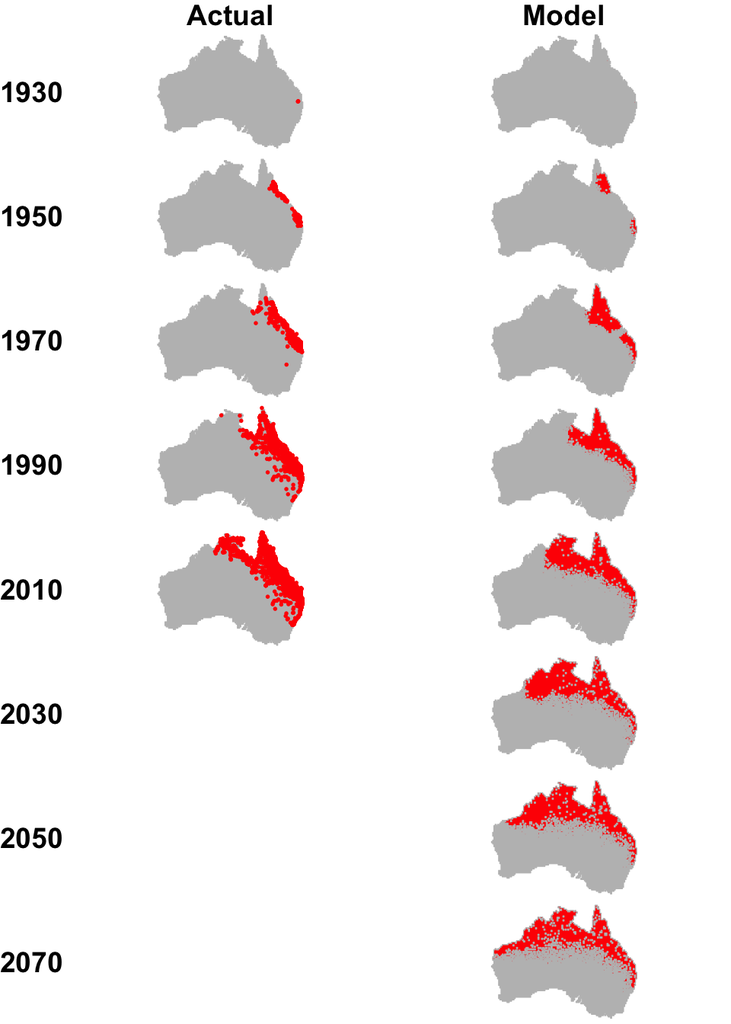

```r
#ChatGPT, 2024
# Plot model data
base_plot<-ggplot()+geom_sf(data=abm_sf, fill="grey", color="grey")+theme_nothing()
yrs<-seq(1, nlayers(tracker_brick), by=7)
plot_list_model<-lapply(yrs, function(i) {
  tracker_sf<-st_as_sf(rasterToPolygons(flatten(tracker_brick[[i]]), fun=function(x) x>0, dissolve=TRUE))
  st_crs(tracker_sf)<-4326
  base_plot+geom_sf(data=tracker_sf, fill="red", color="grey")
})

# Plot actual data
get_spatial_data<-function(data, year_limit) {
  data%>%filter(year<=year_limit)%>%st_as_sf(coords=c("longitude", "latitude"), crs=4326)
}
base_years<-1930+(10/7)*(yrs-1)
years<-base_years[base_years<2030]
spatial_data_list<-lapply(years, get_spatial_data, data=df)
plot_list_actual<-lapply(seq_along(years), function(i) {
  base_plot+geom_sf(data=spatial_data_list[[i]], color="red", size=0.3)
})

# Combine
length_diff<-length(plot_list_model)-length(plot_list_actual)
if(length_diff>=0) {
  plot_list_actual<-append(plot_list_actual, rep(list(NULL), length_diff))
} else {
  plot_list_model<-append(plot_list_model, rep(list(NULL), -length_diff))
}

idxs<-seq(1,length(plot_list_actual), 2)
combined_plots<-lapply(idxs, function(i) {
  list(plot_list_actual[[i]], plot_list_model[[i]])
})
combined_plots<-lapply(combined_plots, function(p) {
  lapply(p, function(x) if(is.null(x)) grid::nullGrob() else x)
})

row_labels<- base_years[idxs]
column_labels<-c("Actual", "Model")
len<-unit(0.5, "npc")
get_txt_grb<-function(label) {textGrob(label, x=len, y=len, just="center", gp=gpar(fontsize=14, fontface="bold"))}
row_label_grobs<-lapply(row_labels, get_txt_grb)
column_label_grobs<-lapply(column_labels, get_txt_grb)

model_plot<-grid.arrange(
  grobs=c(
    list(nullGrob(), column_label_grobs[[1]], column_label_grobs[[2]]),
    do.call(c, lapply(1:length(combined_plots), function(i) {
      list(row_label_grobs[[i]], combined_plots[[i]][[1]], combined_plots[[i]][[2]])
    }))),
  ncol=3, heights=unit.c(unit(1, "lines"), rep(unit(1, "null"), length(combined_plots))),
  widths=unit.c(unit(1.1, "cm"), unit(1, "null"), unit(1, "null")), padding=unit(5, "mm"))
```

## Conclusion

Despite only using data up to 2000, the model can fairly accurately predict toad dispersal from its origin in Queensland. Fitting a function to the westward changes in the invasion front per year could also be effective.

# References

Belbin, L., Wallis, E., Hobern, D., & Zerger, A. (2021). The Atlas of Living Australia: History, current state and future directions. Biodiversity Data Journal 9: e65023. https://doi.org/10.3897/BDJ.9.e65023

ChatGPT. (2024). Plotting Help. Open AI. https://chatgpt.com/share/2ea40add-755a-4f41-ae1e-08afb1e72de6

Elith, J., Kearney, M., & Phillips, S. (2010). The art of modelling range-shifting species. Methods in Ecology and Evolution, 1(4), 330-342. https://doi.org/10.1111/j.2041-210X.2010.00036.x

Fick, S. E., & Hijmans, R. J. (2017). WorldClim 2: new 1-km spatial resolution climate surfaces for global land areas. International Journal of Climatology, 37(12), 4302-4315. https://doi.org/10.1002/joc.5086 https://rmets.onlinelibrary.wiley.com/doi/full/10.1002/joc.5086

Kearney, M., Phillips, B. I., Tracy, C. R., Christian, K. A., Betts, G., & Porter, W. P. (2008). Modelling species distributions without using species distributions: the cane toad in Australia under current and future climates. – Ecography 31: 423–434.

O’Donnell, M. S., & Ignizio, D. A. (2012). Bioclimatic predictors for supporting ecological applications in the conterminous United States (U.S. Geological Survey Data Series 691). U.S. Geological Survey. https://pubs.usgs.gov/ds/691/ds691.pdf

Soley-Guardia, M., Alvarado-Serrano, D. F., & Anderson, R. P. (2024). Top ten hazards to avoid when modeling species distributions: A didactic guide of assumptions, problems, and recommendations. Ecography, 2024(4). https://doi.org/10.1111/ecog.06852

Urban, M. C., Phillips, B. L., Skelly, D. K., & Shine, R. (2007). The cane toad’s (Chaunus [Bufo] marinus) increasing ability to invade Australia is revealed by a dynamically updated range model. Proceedings of the Royal Society B: Biological Sciences, 274(1616), 1413-1419. https://doi.org/10.1098/rspb.2007.0114